# Home advantage in Fantasy Premier League - Notebook

### Sources of home advantage: point-scoring actions

Let’s examine the sources of FPL home advantage. FPL points are based on a variety of different point-scoring actions, as shown in the table below.

| FPL point-scoring action | Points |
| --- | --- |
| Played more than 0 minutes | 1 |
| Played more than 60 minutes | 1 |
| Goal scored (GK / DEF / MID / FWD) | 6 / 6 / 5 / 4 |
| Assist | 3 |
| Every 2 goals conceded (GK / DEF) | -1 |
| Clean sheet (GK / DEF / MID) | 6 / 6 / 1 |
| Every 3 saves (GK) | 2 |
| Yellow card | -1 |
| Red card | -3 |
| Penalty saved (GK) | 5 |
| Penalty missed | -2 |

Source: https://fantasy.premierleague.com/help/rules

Let’s plot the frequency of the different point-scoring actions, for home games and for away games. For this analysis, we will exclude the 2020/21 season, since it exhibits no home advantage with respect to total points.

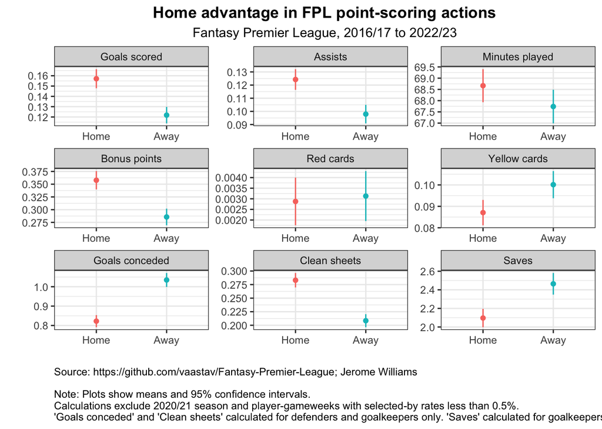

```r
df_for_source_analysis <- home_away_data %>%
  filter(season != '2020/21')

vars_for_all_players <- list('minutes',
                             'goals_scored',
                             'assists',
                             'bonus',
                             'red_cards',
                             'yellow_cards')

calc_stats <- function(df, var_, ...) {
  tibble(mean = mean(df[var_] %>% pull()),
         se = std.error(df[var_]))
}

all_stats <- tibble()
for (var in vars_for_all_players) {
  temp <- df_for_source_analysis %>%
    group_by(home_away) %>%
    group_modify(function(df, ...) { calc_stats(df, var, ...) }) %>%
    mutate(var = var) %>%
    mutate(var = case_when(var == 'assists' ~ 'Assists',
                           var == 'goals_scored' ~ 'Goals scored',
                           var == 'bonus' ~ 'Bonus points',
                           var == 'minutes' ~ 'Minutes played',
                           var == 'red_cards' ~ 'Red cards',
                           var == 'yellow_cards' ~ 'Yellow cards'))
  all_stats <- all_stats %>% bind_rows(temp)
}

def_gk <- df_for_source_analysis %>% filter(position == 'GK' | position == 'DEF')
def_gk_vars <- list('clean_sheets', 'goals_conceded')

def_gk_stats <- tibble()
for (var_ in def_gk_vars) {
  temp <- def_gk %>%
    group_by(home_away) %>%
    group_modify(function(df, ...) { calc_stats(df, var_, ...) }) %>%
    mutate('var' = var_)
  def_gk_stats <- def_gk_stats %>% bind_rows(temp)
}
def_gk_stats <- def_gk_stats %>%
  mutate(var = case_when(var == 'clean_sheets' ~ 'Clean sheets',
                         var == 'goals_conceded' ~ 'Goals conceded'))

gk_only <- df_for_source_analysis %>% filter(position == 'GK')
gk_only_stats <- gk_only %>%
  group_by(home_away) %>%
  group_modify(function(df, ...) { calc_stats(df, 'saves', ...)}) %>%
  mutate('var' = 'Saves')


plotting_data <- all_stats %>%
  bind_rows(def_gk_stats) %>%
  bind_rows(gk_only_stats) %>%
  mutate(var = fct_relevel(var, c('Goals scored', 'Assists', 'Minutes played',
                                  'Bonus points', 'Red cards', 'Yellow cards',
                                  'Goals conceded', 'Clean sheets', 'Saves')))

ggplot(plotting_data, aes(x = home_away, color = home_away)) +
  geom_point(aes(y = mean)) +
  geom_linerange(aes(ymin = mean - 1.96 * se, ymax = mean + 1.96 * se)) +
  facet_wrap(~var, scales = 'free') +
  labs(title = 'Home advantage in FPL point-scoring actions',
       subtitle = 'Fantasy Premier League, 2016/17 to 2022/23',
       caption = 'Source: https://github.com/vaastav/Fantasy-Premier-League; Jerome Williams

Note: Plots show means and 95% confidence intervals.
Calculations exclude 2020/21 season and player-gameweeks with selected-by rates less than 0.5%.
\'Goals conceded\' and \'Clean sheets\' calculated for defenders and goalkeepers only. \'Saves\' calculated for goalkeepers only.',
      x = '',
       y = '',
       color = '') +
  theme_jw() +
  theme(legend.position = 'none')
```

Interestingly, the average number of minutes played (per gameweek/player) is slightly higher for home games than for away games. The difference is small, however—approximately 68.5 minutes for home games vs 67.75 minutes for away games—and is therefore unlikely to be meaningful for FPL points.

### Sources of home advantage: player positions

Let’s also examine home advantage by player position. Players in FPL are assigned one of four positions—GK, DEF, MID, or FWD—which is fixed for the duration of a season. As I explain above, some of the available point-scoring actions differ by position. However, given that almost all actions, including both attacking actions (goals, assists) and defensive actions (clean sheets, goals conceded, saves, etc.), exhibit home advantage, I expect that we will find home advantage across all four positions as well.

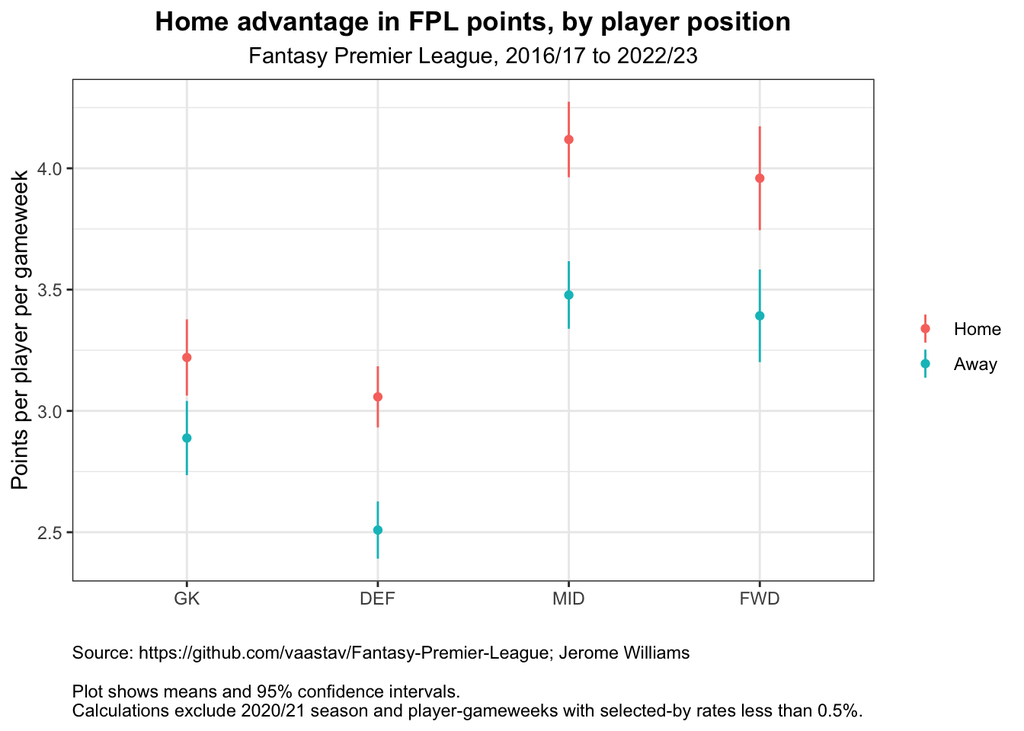

```r
df_for_position_analysis <- home_away_data %>%
  filter(season != '2020/21')

var = 'total_points'
calculate_stats <- function(df) {
  mean_ <- mean(df[var] %>% pull())
  se_ <- std.error(df[var])
  tibble(
    position = df$position[1],
    home_away = df$home_away[1],
    mean = mean_,
    se = se_)
}

pos_stats <- df_for_position_analysis %>%
  split(list(.$position, .$home_away)) %>%
  map(calculate_stats) %>%
  list_rbind() %>%
  mutate(
    position = as_factor(position) %>% fct_relevel(c('GK', 'DEF', 'MID', 'FWD'))
  )

ggplot(pos_stats, aes(x = position, color = home_away, group = home_away)) +
  geom_point(aes(y = mean)) +
  geom_linerange(aes(ymin = mean - 2 * se, ymax = mean + 2 * se)) +
  theme_jw() +
  labs(title = 'Home advantage in FPL points, by player position',
       subtitle = 'Fantasy Premier League, 2016/17 to 2022/23',
       x = '',
       y = 'Points per player per gameweek',
       color = '',
       caption = 'Source: https://github.com/vaastav/Fantasy-Premier-League; Jerome Williams

Plot shows means and 95% confidence intervals.
Calculations exclude 2020/21 season and player-gameweeks with selected-by rates less than 0.5%.')
```

Indeed, we do find home advantage in FPL points for all four positions. Midfielders seem to have the largest difference, as well as the highest number of points on average.

## Do FPL managers take advantage of home advantage?

We have demonstrated that home advantage exists in FPL and exists across seasons and player position. This prompts a question: do managers take advantage of home advantage by selecting home players more frequently than away players?

### Plotting *Percent selected by* for home and away fixtures

To answer this question, let’s look at how ‘Percent selected by’ varies between home matches and away matches.

Ideally, we would also account for the selection of players in managers’ first team of 11 players each gameweek: every gameweek, a manager must choose 11 players from the squad of 15 to “play” in that gameweek (i.e., to score points for the team). The remaining four players sit on the manager’s “bench” and will only score points if they are automatically substituted, which happens if one or more players from the first team of 11 fail to register a single minute of play that gameweek. My guess is that managers may account for home and away fixtures in the first 11 and bench decisions more so than in overall squad selection decisions. Managers are restricted to a single ‘free’ transfer each gameweek—subsequent transfers cost 4 points—meaning that squads change slowly over time and players are typically held by managers for multiple gameweeks (during which they will likely play both home and away matches). However, our FPL dataset includes data only on selection in the squad of 15 (our ‘Percent selected by’ variable) and not on selection in each manager’s first 11 every gameweek.

This time, let’s not exclude 2020/21. I don’t think it was widely known at the time that 2020/21 would result in no discernible home advantage, so I suspect FPL managers did not adjust their behavior that season.

```r
selected_by_stats <- home_away_data %>%
  group_by(season, home_away) %>%
  summarize(
    mean = mean(pct_selected),
    se = std.error(pct_selected),
    n = n()
  )
```

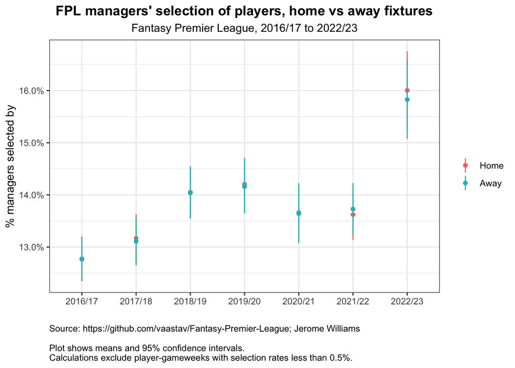

```r
ggplot(selected_by_stats,
       aes(x = season, color = home_away)) +
  geom_point(aes(y = mean)) +
  geom_linerange(aes(ymin = mean - 1.96 * se, ymax = mean + 1.96 * se)) +
  theme_jw() +
  scale_y_continuous(labels = scales::percent_format(scale = 100)) +
  labs(
    title = 'FPL managers\' selection of players, home vs away fixtures',
    subtitle = 'Fantasy Premier League, 2016/17 to 2022/23',
    x = '',
    color = '',
    y = '% managers selected by',
    caption = 'Source: https://github.com/vaastav/Fantasy-Premier-League; Jerome Williams

Plot shows means and 95% confidence intervals.
Calculations exclude player-gameweeks with selection rates less than 0.5%.'
  )
```

The plot above shows that there is no meaningful difference in the average selection rate of players with home fixtures vs players with away fixtures.

However, the plot also prompts some additional questions: what exactly *is* the distribution of ‘Percent selected by’? I am also curious what explains a player’s selection rates: do higher scoring players have higher selection rates? Note that, as explained above, our *Percent selected by* numbers are (i) based on season-end manager counts, and (ii) based on approximate manager counts for some seasons. As a result, *Percent selected by* is an approximation and comparisons across seasons should be taken with a grain of salt.

### The distribution of *Percent selected by*

Let’s look at the distribution of *Percent selected by*. For the reasons mentioned above, we’ll look at the distribution for a single season only, rather than grouping observations from multiple seasons—I selected 2018/19 arbitrarily. As before, let’s exclude player-gameweek observations where *Percent selected by* is less than 0.5%.

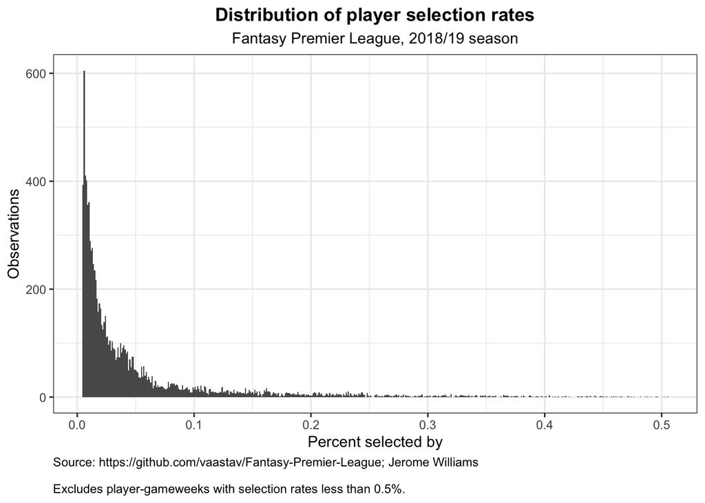

```r
ggplot(gw %>% filter(season == '2018/19', pct_selected > 0.005)) +
  geom_histogram(aes(x = pct_selected), binwidth = 0.001) +
  theme_jw() +
  labs(
    title = 'Distribution of player selection rates',
    subtitle = 'Fantasy Premier League, 2018/19 season',
    x = 'Percent selected by',
    y = 'Observations',
    caption = 'Source: https://github.com/vaastav/Fantasy-Premier-League; Jerome Williams

Excludes player-gameweeks with selection rates less than 0.5%.'
  )
```

### Do more highly selected players score more FPL points?

What we have seen so far also prompts us to ask whether FPL managers are more likely to select players who score more highly. Let’s plot gameweek FPL points against percent selected by.

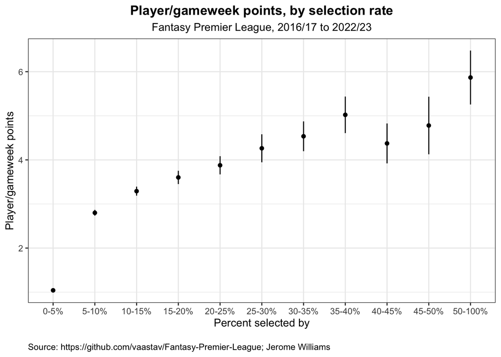

```r
breaks <- c(-0.01, 0.05, 0.1, 0.15, 0.2, 0.25, 0.3, 0.35, 0.4, 0.45, 0.5, 1)
labels <- c('0-5%', '5-10%', '10-15%', '15-20%', '20-25%', '25-30%', '30-35%', '35-40%', '40-45%', '45-50%', '50-100%')
gw2 <- gw %>%
  mutate(pct_selected_bin = cut(pct_selected, breaks = breaks, labels = labels))

stats <- gw2 %>%
  group_by(pct_selected_bin) %>%
  summarize(mean = mean(total_points),
            se = std.error(total_points),
            std = sd(total_points),
            min = min(total_points),
            max = max(total_points),
            n = n()) %>%
  ungroup() %>%
  mutate(n_pct = n / sum(n))

ggplot(stats) +
  geom_point(aes(x = pct_selected_bin, y = mean)) +
  geom_linerange(aes(x = pct_selected_bin, ymin = mean - 1.96 * se, ymax = mean + 1.96*se)) +
  theme_jw() +
  labs(
    title = 'Player/gameweek points, by selection rate',
    subtitle = 'Fantasy Premier League, 2016/17 to 2022/23',
    x = 'Percent selected by',
    y = 'Player/gameweek points',
    caption = '
Source: https://github.com/vaastav/Fantasy-Premier-League; Jerome Williams'
  )
```

Indeed, it does seem appear that FPL managers are more likely to select higher-scoring players. The relationship is consistent up until *Percent selected by* of 40% or so—at which point, there are very few observations.